# Heart Disease Prediction

### Section 3: Model Comparison and Discussion

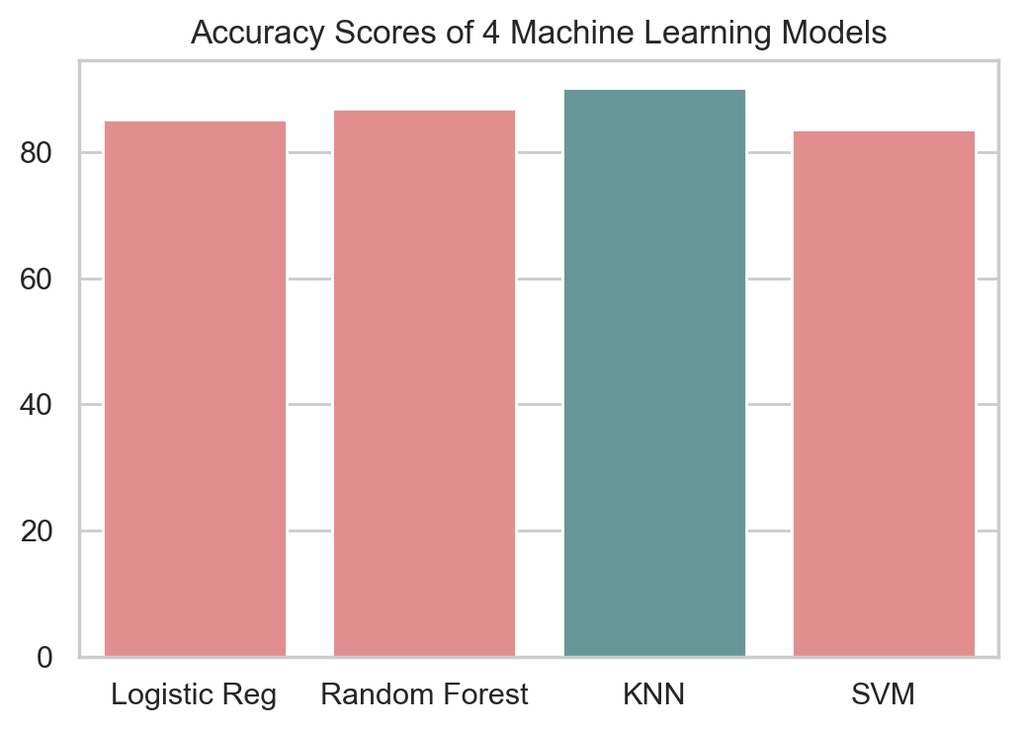

```python
sns.set(style="whitegrid")
colors = ['lightcoral' if (x < max(accuracy_scores)) else 'cadetblue' for x in accuracy_scores ]
sns.barplot(x=[1,2,3,4], y=accuracy_scores,palette=colors)
plt.xticks(np.arange(4),labels=("Logistic Reg", "Random Forest", "KNN", "SVM"))
plt.title("Accuracy Scores of 4 Machine Learning Models")
```

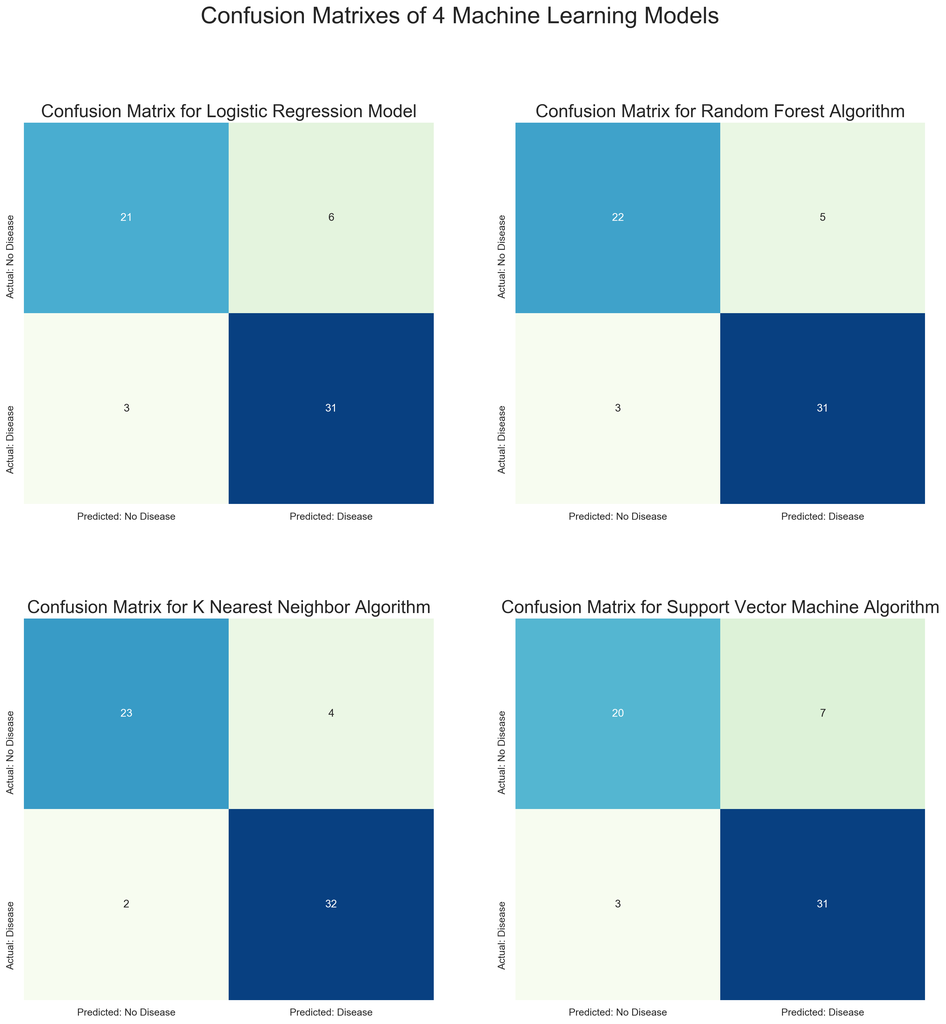

```python
plt.figure(figsize=(18,18))
plt.suptitle("Confusion Matrixes of 4 Machine Learning Models", fontsize=26)
plt.subplots_adjust(wspace = 0.2, hspace= 0.3)

plt.subplot(2,2,1)
sns.heatmap(log_con, annot=True, cmap="GnBu", cbar=False)
plt.title("Confusion Matrix for Logistic Regression Model",fontsize=20)

plt.subplot(2,2,2)
sns.heatmap(rf_con, annot=True, cmap="GnBu",cbar=False)
plt.title("Confusion Matrix for Random Forest Algorithm",fontsize=20)

plt.subplot(2,2,3)
sns.heatmap(knn_con, annot=True, cmap="GnBu",cbar=False)
plt.title("Confusion Matrix for K Nearest Neighbor Algorithm",fontsize=20)
plt.subplot(2,2,4)
sns.heatmap(svm_con, annot=True, cmap="GnBu",cbar=False)
plt.title("Confusion Matrix for Support Vector Machine Algorithm",fontsize=20)
```

[figure not shown]

```python
plt.figure(figsize=(10,18))
plt.suptitle("ROC Curves of 4 Machine Learning Models")
plt.subplots_adjust(wspace = 0.2, hspace= 0.3)
plt.subplot(3,1,1)
plt.plot(fpr, tpr, label="Logistic Regression(auc=%0.2f)"%auc)
plt.plot([0, 1], [0, 1], "o--")
plt.xlim([0.0, 1.0])
plt.ylim([0.0, 1.05])
plt.xlabel('False Positive Rate')
plt.ylabel('True Positive Rate')
plt.title("ROC Curve of Logistic Regression Model")
plt.legend(loc="lower right")

plt.subplot(3,1,2)
plt.plot(rf_fpr, rf_tpr, label="Random Forest(auc=%0.2f)"%rf_auc)
plt.plot([0, 1], [0, 1], "o--")
plt.xlim([0.0, 1.0])
plt.ylim([0.0, 1.05])
plt.xlabel('False Positive Rate')
plt.ylabel('True Positive Rate')
plt.title("ROC Curve of Random Forest Algorithm")
plt.legend(loc="lower right")

plt.subplot(3,1,3)
plt.plot(knn_fpr, knn_tpr, label="KNN(auc=%0.2f)"%knn_auc)
plt.plot([0, 1], [0, 1], "o--")
plt.xlim([0.0, 1.0])
plt.ylim([0.0, 1.05])
plt.xlabel('False Positive Rate')
plt.ylabel('True Positive Rate')
plt.title("ROC Curve of KNN Algorithm")
plt.legend(loc="lower right")
```

To conclude, all four models correctly prodicted more than 80% of heart disease status. As we compare the accuracy scores and confusion matrices, the K nearnest neighbor model has the best performance. For future steps, I am very interested in fine tuning each machine learning model to achieve better performances. The accuracy of the KNN model is 90%, which can potentially be improved. We should always aim for perfection for machine learning in the healthcare field because the prediction could potentially save lifes.

Further, I also hope to read more articles on model selection and comparison. It would be save a lot of time and resources if I was able to select the best performing model from the very beginning. I plan to get more educated on the ideal context to use different machine learning models.